# Assignment 3: CFA

Rushabh Barbhaya

2021-01-31

## CFA Assignment

### The Data and Libraries

Import the dataset for this assignment (included online), and load the `lavaan` and `semPaths` libraries.

```r
library(lavaan)
```

```r
library(semPlot)
data <- read.csv("assignment3_data.csv")
names(data)[1] <- "inform"
```

### Data screening (shortened):

Assume that the data is accurate. Screen the data for outliers.

```r
mahal = mahalanobis(data,
                    colMeans(data),
                    cov(data))
cutoff = qchisq(1-.001, ncol(data))
outputTable = table(mahal < cutoff)
```

QUESTION: How many outliers did you have?  
ANSWER: $1$

Exclude any multivariate outliers.

```r
data2 = subset(data, mahal < cutoff)
```

### Confirmatory Factor Analysis

The picture for this assignment is included on Canvas. If you download it into the same folder as this markdown file, you can knit it with your document. We will work again with IQ data to determine the overall structure and best type of model for the data.

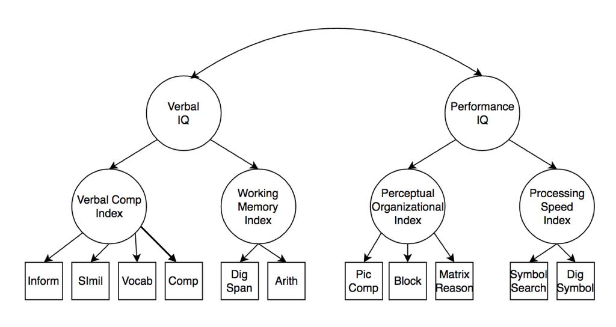

### Four-Factor Model

In this section, you should build a four-factor model represented by Verbal Comp, Working Memory, Perceptual Organization, and Processing Speed. Include all four steps of modeling: build, analyze, summarize, diagram.

```r
FourModel = '
VCI =~ inform + simil + vocab + compreh
WMI =~ digspan + arith
POI =~ piccomp + block + matrixreason
PSI =~ symbolsearch + digsym
'
FourModel.fit = cfa(FourModel, data = data2)
summary(FourModel.fit, standardize = T, rsquare = T, fit.measure = T)
```

```
## lavaan 0.6-7 ended normally after 121 iterations
##
##   Estimator                                         ML
##   Optimization method                           NLMINB
##   Number of free parameters                         28
##
##   Number of observations                           123
##
## Model Test User Model:
##
##   Test statistic                                74.369
##   Degrees of freedom                                38
##   P-value (Chi-square)                           0.000
##
## Model Test Baseline Model:
##
##   Test statistic                               327.999
##   Degrees of freedom                                55
##   P-value                                        0.000
##
## User Model versus Baseline Model:
##
##   Comparative Fit Index (CFI)                    0.867
##   Tucker-Lewis Index (TLI)                       0.807
##
## Loglikelihood and Information Criteria:
##
##   Loglikelihood user model (H0)              -3713.444
##   Loglikelihood unrestricted model (H1)      -3676.260
##
##   Akaike (AIC)                                7482.888
##   Bayesian (BIC)                              7561.629
##   Sample-size adjusted Bayesian (BIC)         7473.096
##
## Root Mean Square Error of Approximation:
##
##   RMSEA                                          0.088
##   90 Percent confidence interval - lower         0.058
##   90 Percent confidence interval - upper         0.118
##   P-value RMSEA <= 0.05                          0.022
```

[output cut: 57 more lines]

```
##     PSI               7.769    4.408    1.762    0.078    1.000    1.000
##
## R-Square:
##                    Estimate
##     inform            0.380
##     simil             0.290
##     vocab             0.841
##     compreh           0.252
##     digspan           0.217
##     arith             0.798
##     piccomp           0.192
##     block             0.396
##     matrixreason      0.178
##     symbolsearch      0.552
##     digsym            0.058
```

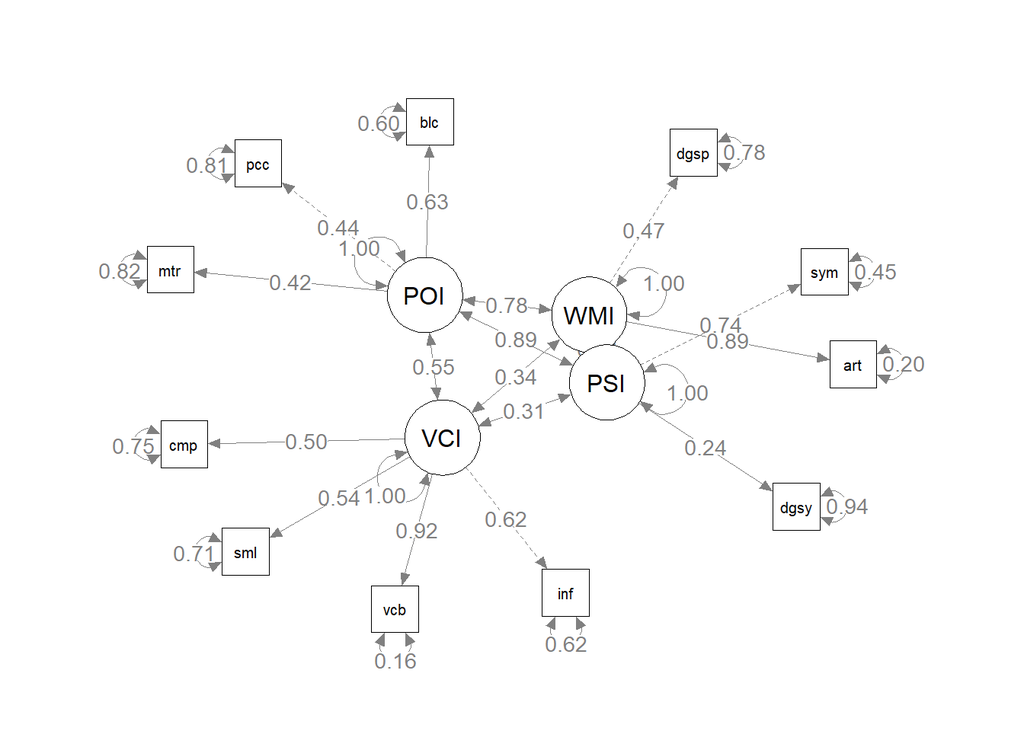

```r
semPaths(FourModel.fit, whatLabels = 'std', layout = 'spring', edge.label.cex = 1)
```

```r
fitmeasures(FourModel.fit)
```

```
##                npar                fmin               chisq                  df
##              28.000               0.302              74.369              38.000
##              pvalue      baseline.chisq         baseline.df     baseline.pvalue
##               0.000             327.999              55.000               0.000
##                 cfi                 tli                nnfi                 rfi
##               0.867               0.807               0.807               0.672
##                 nfi                pnfi                 ifi                 rni
##               0.773               0.534               0.875               0.867
##                logl   unrestricted.logl                 aic                 bic
##           -3713.444           -3676.260            7482.888            7561.629
##              ntotal                bic2               rmsea      rmsea.ci.lower
##             123.000            7473.096               0.088               0.058
##      rmsea.ci.upper        rmsea.pvalue                 rmr          rmr_nomean
##               0.118               0.022               1.676               1.676
##                srmr        srmr_bentler srmr_bentler_nomean                crmr
##               0.076               0.076               0.076               0.084
##         crmr_nomean          srmr_mplus   srmr_mplus_nomean               cn_05
##               0.084               0.076               0.076              89.292
##               cn_01                 gfi                agfi                pgfi
##             102.157               0.907               0.839               0.522
##                 mfi                ecvi
##               0.863               1.060
```

### Two-Factor Model

In this section, you should build a two-factor model represented by Verbal IQ and Performance IQ by collapsing the latents together (you will do hierarchical in another section). Include all four steps of modeling: build, analyze, summarize, diagram.

```r
TwoModel = '
VIQ =~ inform + simil + vocab + compreh + digspan + arith
PIQ =~ piccomp + block + matrixreason + symbolsearch + digsym
'
TwoModel.fit = cfa(TwoModel, data = data2)
summary(TwoModel.fit, standardize = T, rsquare = T, fit.measure = T)
```

```
## lavaan 0.6-7 ended normally after 61 iterations
##
##   Estimator                                         ML
##   Optimization method                           NLMINB
##   Number of free parameters                         23
##
##   Number of observations                           123
##
## Model Test User Model:
##
##   Test statistic                               118.864
##   Degrees of freedom                                43
##   P-value (Chi-square)                           0.000
##
## Model Test Baseline Model:
##
##   Test statistic                               327.999
##   Degrees of freedom                                55
##   P-value                                        0.000
##
## User Model versus Baseline Model:
##
##   Comparative Fit Index (CFI)                    0.722
##   Tucker-Lewis Index (TLI)                       0.645
##
## Loglikelihood and Information Criteria:
##
##   Loglikelihood user model (H0)              -3735.692
##   Loglikelihood unrestricted model (H1)      -3676.260
##
##   Akaike (AIC)                                7517.384
##   Bayesian (BIC)                              7582.064
##   Sample-size adjusted Bayesian (BIC)         7509.340
##
## Root Mean Square Error of Approximation:
##
##   RMSEA                                          0.120
##   90 Percent confidence interval - lower         0.094
##   90 Percent confidence interval - upper         0.146
##   P-value RMSEA <= 0.05                          0.000
```

[output cut: 46 more lines]

```
##     PIQ               1.689    0.585    2.886    0.004    1.000    1.000
##
## R-Square:
##                    Estimate
##     inform            0.351
##     simil             0.348
##     vocab             0.696
##     compreh           0.290
##     digspan           0.083
##     arith             0.161
##     piccomp           0.350
##     block             0.356
##     matrixreason      0.162
##     symbolsearch      0.324
##     digsym            0.041
```

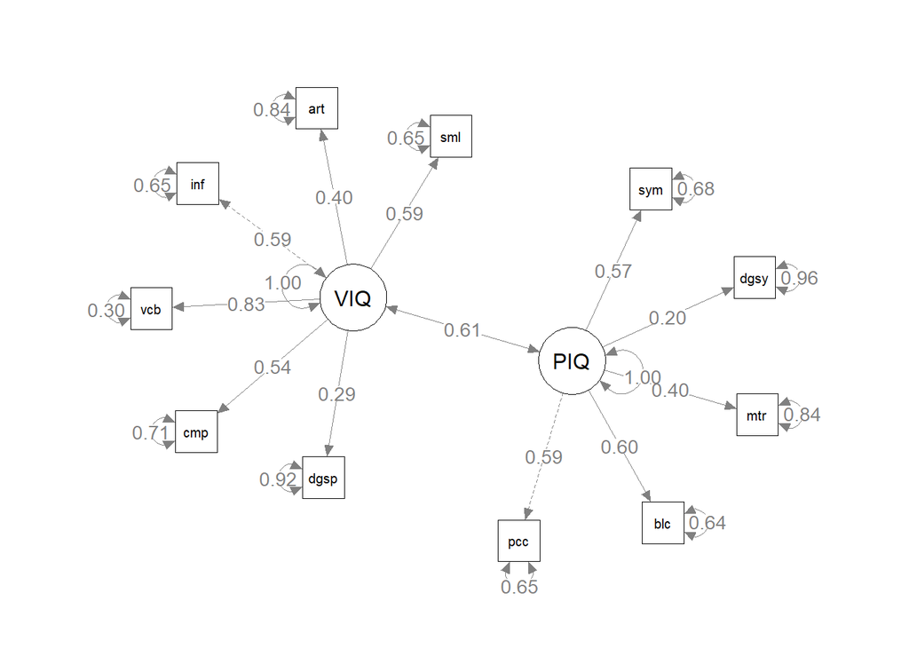

```r
semPaths(TwoModel.fit, whatLabels = 'std', edge.label.cex = 1, layout = 'spring')
```

```r
fitmeasures(TwoModel.fit)
```

```
##                npar                fmin               chisq                  df
##              23.000               0.483             118.864              43.000
##              pvalue      baseline.chisq         baseline.df     baseline.pvalue
##               0.000             327.999              55.000               0.000
##                 cfi                 tli                nnfi                 rfi
##               0.722               0.645               0.645               0.536
##                 nfi                pnfi                 ifi                 rni
##               0.638               0.498               0.734               0.722
##                logl   unrestricted.logl                 aic                 bic
##           -3735.692           -3676.260            7517.384            7582.064
##              ntotal                bic2               rmsea      rmsea.ci.lower
##             123.000            7509.340               0.120               0.094
##      rmsea.ci.upper        rmsea.pvalue                 rmr          rmr_nomean
##               0.146               0.000               2.174               2.174
##                srmr        srmr_bentler srmr_bentler_nomean                crmr
##               0.094               0.094               0.094               0.102
##         crmr_nomean          srmr_mplus   srmr_mplus_nomean               cn_05
##               0.102               0.094               0.094              62.367
##               cn_01                 gfi                agfi                pgfi
##              70.806               0.857               0.781               0.559
##                 mfi                ecvi
##               0.735               1.340
```

### One-Factor Model

In this section, you should build a one-factor model representing IQ with all of the measured variables on one overall IQ latent. Include all four steps of modeling: build, analyze, summarize, diagram.

```r
OneModel = '
IQ =~ inform + simil + vocab + compreh + digspan + arith + piccomp + block + matrixreason + symbolsearch + digsym
'
OneModel.fit = cfa(OneModel, data = data2)
summary(OneModel.fit, standardize = T, rsquare = T, fit.measure = T)
```

```
## lavaan 0.6-7 ended normally after 52 iterations
##
##   Estimator                                         ML
##   Optimization method                           NLMINB
##   Number of free parameters                         22
##
##   Number of observations                           123
##
## Model Test User Model:
##
##   Test statistic                               136.747
##   Degrees of freedom                                44
##   P-value (Chi-square)                           0.000
##
## Model Test Baseline Model:
##
##   Test statistic                               327.999
##   Degrees of freedom                                55
##   P-value                                        0.000
##
## User Model versus Baseline Model:
##
##   Comparative Fit Index (CFI)                    0.660
##   Tucker-Lewis Index (TLI)                       0.575
##
## Loglikelihood and Information Criteria:
##
##   Loglikelihood user model (H0)              -3744.633
##   Loglikelihood unrestricted model (H1)      -3676.260
##
##   Akaike (AIC)                                7533.267
##   Bayesian (BIC)                              7595.135
##   Sample-size adjusted Bayesian (BIC)         7525.572
##
## Root Mean Square Error of Approximation:
##
##   RMSEA                                          0.131
##   90 Percent confidence interval - lower         0.106
##   90 Percent confidence interval - upper         0.156
##   P-value RMSEA <= 0.05                          0.000
```

[output cut: 39 more lines]

```
##     IQ                4.971    1.794    2.771    0.006    1.000    1.000
##
## R-Square:
##                    Estimate
##     inform            0.270
##     simil             0.362
##     vocab             0.538
##     compreh           0.300
##     digspan           0.102
##     arith             0.232
##     piccomp           0.305
##     block             0.199
##     matrixreason      0.126
##     symbolsearch      0.152
##     digsym            0.008
```

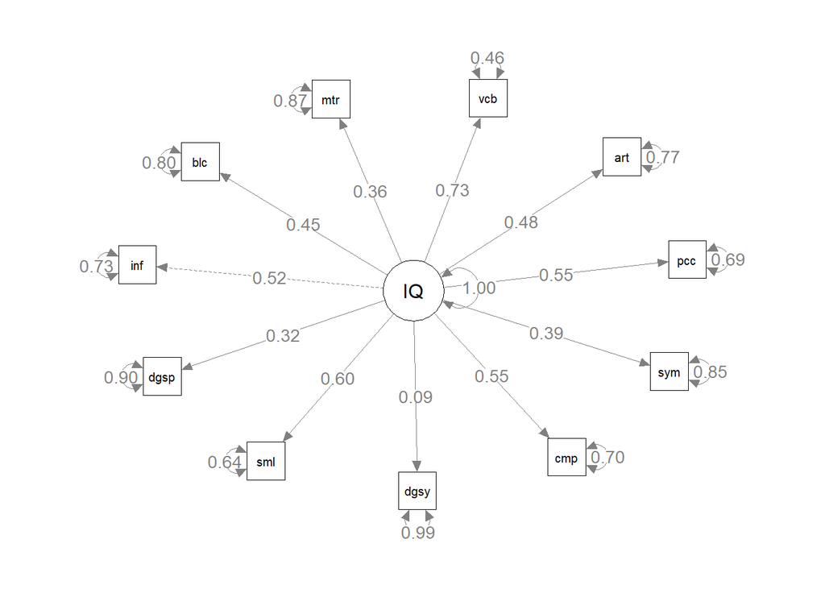

```r
semPaths(OneModel.fit, whatLabels = 'std', edge.label.cex = 1, layout = 'spring')
```

```r
fitmeasures(OneModel.fit)
```

```
##                npar                fmin               chisq                  df
##              22.000               0.556             136.747              44.000
##              pvalue      baseline.chisq         baseline.df     baseline.pvalue
##               0.000             327.999              55.000               0.000
##                 cfi                 tli                nnfi                 rfi
##               0.660               0.575               0.575               0.479
##                 nfi                pnfi                 ifi                 rni
##               0.583               0.466               0.673               0.660
##                logl   unrestricted.logl                 aic                 bic
##           -3744.633           -3676.260            7533.267            7595.135
##              ntotal                bic2               rmsea      rmsea.ci.lower
##             123.000            7525.572               0.131               0.106
##      rmsea.ci.upper        rmsea.pvalue                 rmr          rmr_nomean
##               0.156               0.000               2.441               2.441
##                srmr        srmr_bentler srmr_bentler_nomean                crmr
##               0.095               0.095               0.095               0.104
##         crmr_nomean          srmr_mplus   srmr_mplus_nomean               cn_05
##               0.104               0.095               0.095              55.401
##               cn_01                 gfi                agfi                pgfi
##              62.802               0.837               0.756               0.558
##                 mfi                ecvi
##               0.686               1.469
```

### Interpretation

QUESTION: Examine all the models for potential problems. Do they all converge correctly? Remember to check for variance, correlation, r-square, and standard error issues.

ANSWER FOUR FACTOR:  
*Loadings:* They load well in the model. Except for the variable ‘digsym’  
*Variance:* Some variances are too high, which may skew the results  
*Covariance:* Some of them look good, some don’t  
*r-square:* All the values for are less than 1, which is good. some values are quite low.  
*Error variables:* Good score on SRMR

ANSWER TWO FACTOR:  
*Loadings:* Not all variables load well  
*Variance, Covariance, r-square, Error variance:* all are mixed bag. Some laod good, some not so good.

ANSWER ONE FACTOR:  
Borderline results. Not decent. I would not recommend this model.

For *only* the models that converged correctly, compare them using `anova()` or AIC and ECVI.

```r
anova(FourModel.fit, TwoModel.fit)
```

```
## Chi-Squared Difference Test
##
##               Df    AIC    BIC   Chisq Chisq diff Df diff Pr(>Chisq)
## FourModel.fit 38 7482.9 7561.6  74.369
## TwoModel.fit  43 7517.4 7582.1 118.864     44.496       5  1.837e-08 ***
## ---
## Signif. codes:  0 '***' 0.001 '**' 0.01 '*' 0.05 '.' 0.1 ' ' 1
```

```r
fitmeasures(FourModel.fit, c("aic", "ecvi"))
```

```
##      aic     ecvi
## 7482.888    1.060
```

```r
fitmeasures(TwoModel.fit ,c("aic", "ecvi"))
```

```
##      aic     ecvi
## 7517.384    1.340
```

QUESTION: Which model was the best? ANSWER: 4-Factor model works really. AIC and BIC scores aren’t much different. But the model are significantly different enough. AIC and ECVI of 4-Factor Model is better.

For the best model only, check the modification indices.

```r
modificationindices(FourModel.fit, sort. = T)
```

```
##              lhs op          rhs     mi    epc sepc.lv sepc.all sepc.nox
## 67        inform ~~        vocab 17.015 14.026  14.026    1.577    1.577
## 66        inform ~~        simil  9.969 -2.813  -2.813   -0.355   -0.355
## 77         simil ~~      compreh  9.769  2.391   2.391    0.318    0.318
## 35           VCI =~      piccomp  9.024  0.304   0.805    0.366    0.366
## 106        arith ~~      piccomp  8.642 -1.641  -1.641   -0.620   -0.620
## 41           WMI =~        simil  6.089  0.350   0.660    0.237    0.237
## 81         simil ~~        block  5.875 -3.138  -3.138   -0.235   -0.235
## 60           PSI =~      compreh  5.824  0.346   0.964    0.260    0.260
## 51           POI =~        vocab  5.794 -1.975  -1.901   -0.288   -0.288
## 87         vocab ~~        arith  5.424 -2.788  -2.788   -0.790   -0.790
## 79         simil ~~        arith  4.653  1.125   1.125    0.358    0.358
## 107        arith ~~        block  4.118  4.540   4.540    0.596    0.596
## 42           WMI =~        vocab  4.073 -0.737  -1.391   -0.210   -0.210
## 50           POI =~        simil  3.850  0.606   0.584    0.210    0.210
```

[output cut: 72 more lines]

QUESTION: Should any of the items be moved or use correlated residuals? ANSWER: inform and vocab correlated should be used.

### Hierarchical CFA

Use a general IQ factor to predict your two-factor model. Include all four steps of modeling: build, analyze, summarize, diagram.

```r
TwoFactorModel = '
VCI =~ inform + simil + vocab + compreh
WMI =~ digspan + arith
POI =~ piccomp + block + matrixreason
PSI =~ symbolsearch + digsym
piccomp ~~ 4.870985*piccomp
block ~~ 53.90284*block
matrixreason ~~ 6.128749*matrixreason
VIQ =~ VCI + WMI
PIQ =~ POI + PSI
'
TwoFactorModel.fit = cfa(TwoFactorModel, data = data2)
summary(TwoFactorModel.fit, standardized = T, rsquare = T, fit.measure = T)
```

```
## lavaan 0.6-7 ended normally after 100 iterations
##
##   Estimator                                         ML
##   Optimization method                           NLMINB
##   Number of free parameters                         24
##
##   Number of observations                           123
##
## Model Test User Model:
##
##   Test statistic                                87.697
##   Degrees of freedom                                42
##   P-value (Chi-square)                           0.000
##
## Model Test Baseline Model:
##
##   Test statistic                               327.999
##   Degrees of freedom                                55
##   P-value                                        0.000
##
## User Model versus Baseline Model:
##
##   Comparative Fit Index (CFI)                    0.833
##   Tucker-Lewis Index (TLI)                       0.781
##
## Loglikelihood and Information Criteria:
##
##   Loglikelihood user model (H0)              -3720.108
##   Loglikelihood unrestricted model (H1)      -3676.260
##
##   Akaike (AIC)                                7488.217
##   Bayesian (BIC)                              7555.709
##   Sample-size adjusted Bayesian (BIC)         7479.823
##
## Root Mean Square Error of Approximation:
##
##   RMSEA                                          0.094
##   90 Percent confidence interval - lower         0.066
##   90 Percent confidence interval - upper         0.122
##   P-value RMSEA <= 0.05                          0.007
```

[output cut: 62 more lines]

```
##     piccomp           0.087
##     block             0.203
##     matrixreason      0.091
##     inform            0.380
##     simil             0.286
##     vocab             0.856
##     compreh           0.244
##     digspan           0.217
##     arith             0.798
##     symbolsearch      0.484
##     digsym            0.066
##     VCI               0.231
##     WMI               0.493
##     POI                  NA
##     PSI               0.343
```

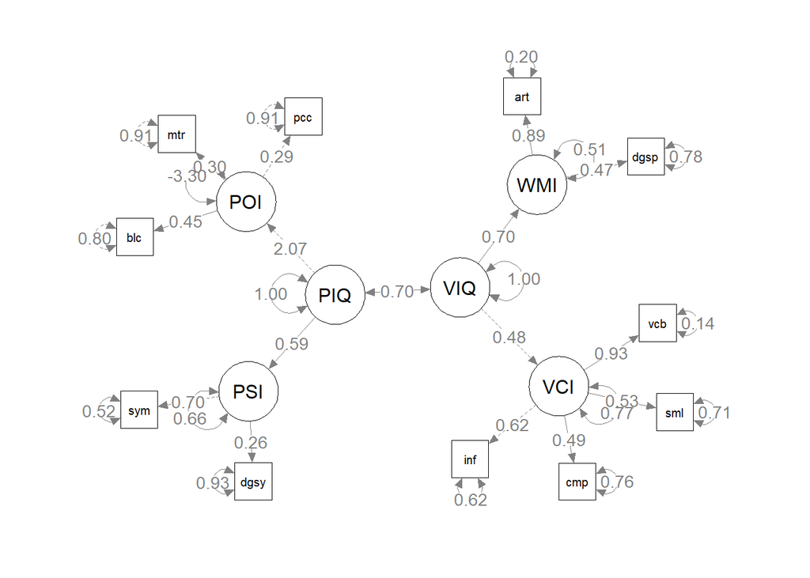

```r
semPaths(TwoFactorModel.fit, whatLabels = 'std', edge.label.cex = 1, layout = 'spring')
```

```r
fitmeasures(TwoFactorModel.fit)
```

```
##                npar                fmin               chisq                  df
##              24.000               0.356              87.697              42.000
##              pvalue      baseline.chisq         baseline.df     baseline.pvalue
##               0.000             327.999              55.000               0.000
##                 cfi                 tli                nnfi                 rfi
##               0.833               0.781               0.781               0.650
##                 nfi                pnfi                 ifi                 rni
##               0.733               0.559               0.840               0.833
##                logl   unrestricted.logl                 aic                 bic
##           -3720.108           -3676.260            7488.217            7555.709
##              ntotal                bic2               rmsea      rmsea.ci.lower
##             123.000            7479.823               0.094               0.066
##      rmsea.ci.upper        rmsea.pvalue                 rmr          rmr_nomean
##               0.122               0.007               2.465               2.465
##                srmr        srmr_bentler srmr_bentler_nomean                crmr
##               0.093               0.093               0.093               0.096
##         crmr_nomean          srmr_mplus   srmr_mplus_nomean               cn_05
##               0.096               0.095               0.095              82.522
##               cn_01                 gfi                agfi                pgfi
##              93.858               0.896               0.837               0.570
##                 mfi                ecvi
##               0.830               1.103
```

QUESTION: Does the analysis support a hierarchical model? ANSWER: Unable to remove the Heywood case, can’t answer this question

### Bifactor CFA

*NOTE*: To fix Heywood cases here, you should calculate the variance for the items that are giving Heywood problems. Fix those variances to the variance in the dataset one at a time until the negative variances go away.

So, calculate variance with `var(dataframe$column)`. Then include that variance as a new line in your model with `column ~~ VARIANCE * column` where VARIANCE is the number you just calculated.

For your two-factor model, include a generalized IQ factor as a bifactor model. Include all four steps of modeling: build, analyze, summarize, diagram.

```r
bifactor = '
VCI =~ inform + simil + vocab + compreh
WMI =~ digspan + arith
POI =~ piccomp + block + matrixreason
PSI =~ symbolsearch + digsym
IQ =~ inform + simil + vocab + compreh + digspan + arith + piccomp + block + matrixreason + symbolsearch + digsym
digsym ~~ 133.1499*digsym
block ~~ 53.90284*block
symbolsearch ~~ 14.18153*symbolsearch
'
bifactor.fit = cfa(bifactor, data = data2, check.gradient = F)
summary(bifactor.fit, standardized = T, rsquare = T, fit.measures = T)
```

```
## lavaan 0.6-7 ended normally after 3777 iterations
##
##   Estimator                                         ML
##   Optimization method                           NLMINB
##   Number of free parameters                         40
##
##   Number of observations                           123
##
## Model Test User Model:
##
##   Test statistic                                55.216
##   Degrees of freedom                                26
##   P-value (Chi-square)                           0.001
##
## Model Test Baseline Model:
##
##   Test statistic                               327.999
##   Degrees of freedom                                55
##   P-value                                        0.000
##
## User Model versus Baseline Model:
##
##   Comparative Fit Index (CFI)                    0.893
##   Tucker-Lewis Index (TLI)                       0.774
##
## Loglikelihood and Information Criteria:
##
##   Loglikelihood user model (H0)              -3703.868
##   Loglikelihood unrestricted model (H1)      -3676.260
##
##   Akaike (AIC)                                7487.736
##   Bayesian (BIC)                              7600.223
##   Sample-size adjusted Bayesian (BIC)         7473.746
##
## Root Mean Square Error of Approximation:
##
##   RMSEA                                          0.096
##   90 Percent confidence interval - lower         0.060
##   90 Percent confidence interval - upper         0.131
##   P-value RMSEA <= 0.05                          0.020
```

[output cut: 75 more lines]

```
##     IQ                 5.926       NA                      1.000    1.000
##
## R-Square:
##                    Estimate
##     digsym            -0.000
##     block              0.158
##     symbolsearch       0.043
##     inform             0.395
##     simil             -0.557
##     vocab              0.866
##     compreh            0.184
##     digspan            0.202
##     arith              0.897
##     piccomp            0.164
##     matrixreason       0.057
```

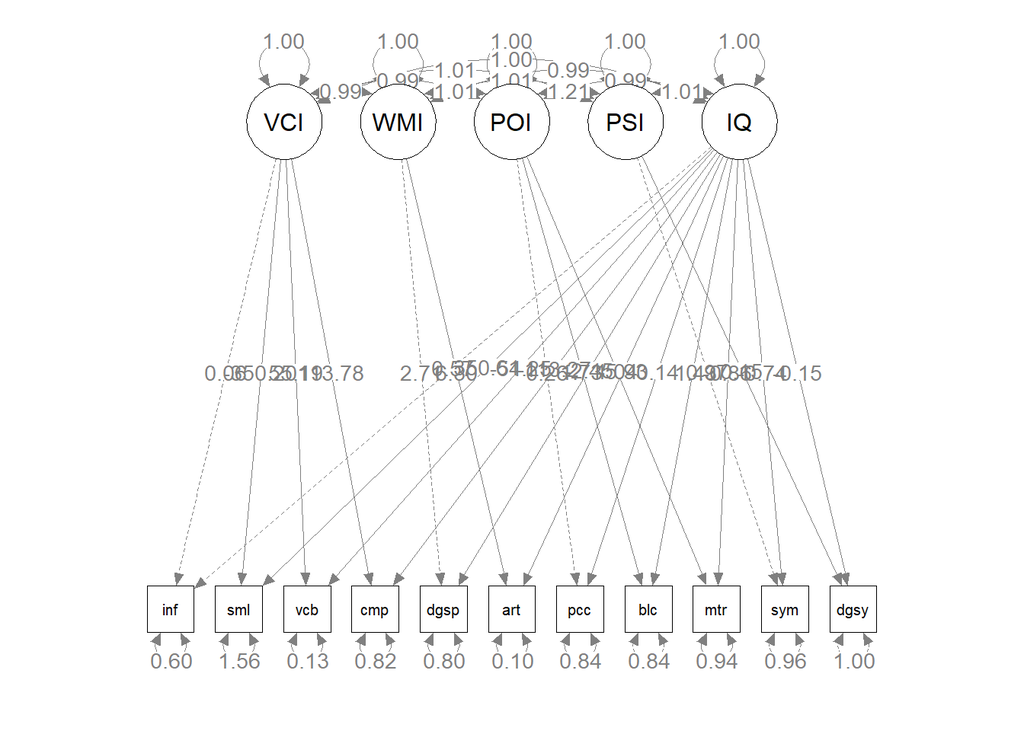

```r
semPaths(bifactor.fit, whatLabels = 'std', edge.label.cex = 1, layout = 'tree')
```

```r
fitmeasures(bifactor.fit)
```

```
##                npar                fmin               chisq                  df
##              40.000               0.224              55.216              26.000
##              pvalue      baseline.chisq         baseline.df     baseline.pvalue
##               0.001             327.999              55.000               0.000
##                 cfi                 tli                nnfi                 rfi
##               0.893               0.774               0.774               0.644
##                 nfi                pnfi                 ifi                 rni
##               0.832               0.393               0.903               0.893
##                logl   unrestricted.logl                 aic                 bic
##           -3703.868           -3676.260            7487.736            7600.223
##              ntotal                bic2               rmsea      rmsea.ci.lower
##             123.000            7473.746               0.096               0.060
##      rmsea.ci.upper        rmsea.pvalue                 rmr          rmr_nomean
##               0.131               0.020               2.204               2.204
##                srmr        srmr_bentler srmr_bentler_nomean                crmr
##               0.077               0.077               0.077               0.080
##         crmr_nomean          srmr_mplus   srmr_mplus_nomean               cn_05
##               0.080               0.077               0.077              87.621
##               cn_01                 gfi                agfi                pgfi
##             102.672               0.925               0.810               0.364
##                 mfi                ecvi
##               0.888               1.099
```

### Full SEM

For this model, you should build a three-factor version of the IQ scale where processing speed and perceptual organization are combined together, and working memory and verbal comp are two separate factors. Use the combined perceptual/processing speed to predict working memory, and working memory to predict verbal comp (i.e., PSI/POI –> WMI –> VCI). Include all four steps of modeling: build, analyze, summarize, diagram.

```r
fullSEM = '
PI =~ piccomp + block + matrixreason + symbolsearch + digsym
WMI =~ digspan + arith
VCI =~ inform + simil + vocab + compreh
WMI ~ PI
VCI ~ WMI
'
fullSEM.fit = sem(fullSEM, data = data2)
summary(fullSEM.fit, standardized = T, rsquare = T, fit.measures = T)
```

```
## lavaan 0.6-7 ended normally after 75 iterations
##
##   Estimator                                         ML
##   Optimization method                           NLMINB
##   Number of free parameters                         24
##
##   Number of observations                           123
##
## Model Test User Model:
##
##   Test statistic                                94.774
##   Degrees of freedom                                42
##   P-value (Chi-square)                           0.000
##
## Model Test Baseline Model:
##
##   Test statistic                               327.999
##   Degrees of freedom                                55
##   P-value                                        0.000
##
## User Model versus Baseline Model:
##
##   Comparative Fit Index (CFI)                    0.807
##   Tucker-Lewis Index (TLI)                       0.747
##
## Loglikelihood and Information Criteria:
##
##   Loglikelihood user model (H0)              -3723.647
##   Loglikelihood unrestricted model (H1)      -3676.260
##
##   Akaike (AIC)                                7495.294
##   Bayesian (BIC)                              7562.786
##   Sample-size adjusted Bayesian (BIC)         7486.900
##
## Root Mean Square Error of Approximation:
##
##   RMSEA                                          0.101
##   90 Percent confidence interval - lower         0.074
##   90 Percent confidence interval - upper         0.128
##   P-value RMSEA <= 0.05                          0.002
```

[output cut: 52 more lines]

```
## R-Square:
##                    Estimate
##     piccomp           0.243
##     block             0.507
##     matrixreason      0.173
##     symbolsearch      0.279
##     digsym            0.034
##     digspan           0.232
##     arith             0.597
##     inform            0.380
##     simil             0.289
##     vocab             0.853
##     compreh           0.243
##     WMI               0.516
##     VCI               0.208
```

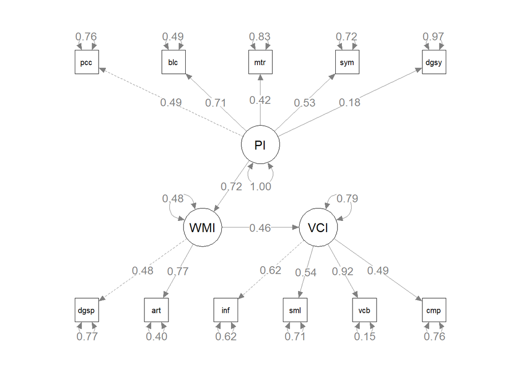

```r
semPaths(fullSEM.fit, whatLabels = "std", layout = "tree", edge.label.cex = 1)
```

```r
fitmeasures(fullSEM.fit)
```

```
##                npar                fmin               chisq                  df
##              24.000               0.385              94.774              42.000
##              pvalue      baseline.chisq         baseline.df     baseline.pvalue
##               0.000             327.999              55.000               0.000
##                 cfi                 tli                nnfi                 rfi
##               0.807               0.747               0.747               0.622
##                 nfi                pnfi                 ifi                 rni
##               0.711               0.543               0.815               0.807
##                logl   unrestricted.logl                 aic                 bic
##           -3723.647           -3676.260            7495.294            7562.786
##              ntotal                bic2               rmsea      rmsea.ci.lower
##             123.000            7486.900               0.101               0.074
##      rmsea.ci.upper        rmsea.pvalue                 rmr          rmr_nomean
##               0.128               0.002               1.838               1.838
##                srmr        srmr_bentler srmr_bentler_nomean                crmr
##               0.092               0.092               0.092               0.101
##         crmr_nomean          srmr_mplus   srmr_mplus_nomean               cn_05
##               0.101               0.092               0.092              76.435
##               cn_01                 gfi                agfi                pgfi
##              86.924               0.880               0.812               0.560
##                 mfi                ecvi
##               0.807               1.161
```

```r
modificationindices(fullSEM.fit, sort. = T)
```

```
##              lhs op          rhs     mi    epc sepc.lv sepc.all sepc.nox
## 100       inform ~~        vocab 16.841 14.941  14.941    1.743    1.743
## 43           VCI =~      piccomp 10.289  0.264   0.698    0.318    0.318
## 103        simil ~~      compreh 10.218  2.464   2.464    0.325    0.325
## 99        inform ~~        simil 10.207 -2.898  -2.898   -0.365   -0.365
## 37           WMI =~ symbolsearch 10.015 -1.336  -2.610   -0.696   -0.696
## 97         arith ~~        vocab  8.285 -3.559  -3.559   -0.742   -0.742
## 64         block ~~        arith  7.905  5.169   5.169    0.533    0.533
## 60         block ~~ matrixreason  7.875 -4.494  -4.494   -0.390   -0.390
## 79  symbolsearch ~~        arith  6.614 -2.187  -2.187   -0.363   -0.363
## 28            PI =~      digspan  6.168 -2.383  -2.584   -0.638   -0.638
## 49           VCI =~        arith  6.168 -0.446  -1.180   -0.396   -0.396
## 66         block ~~        simil  6.044 -3.265  -3.265   -0.271   -0.271
## 109          VCI  ~           PI  5.610  1.444   0.592    0.592    0.592
## 106           PI ~~          VCI  5.610  1.698   0.665    0.665    0.665
```

[output cut: 68 more lines]

QUESTION: Are there any non-significant paths in the structural model? ANSWER: No

QUESTION: How much variance are you accounting for in the structural model (use the r-squared section of the output)? ANSWER: Not a lot. Some are high bit all the others are close enough